# A2 - Análitica descriptiva e inferencial

Reinaldo Quintero

2022-04-02

# 1. Lectura del fichero y preparación de los datos

Leed el fichero CensusIncome_clean.csv y guardad los datos en un objeto con identificador denominado censo. A continuación, verificad que los datos se han cargado correctamente.

```r
censo <- read.csv('CensusIncome_clean.csv')

head(censo)
```

```
##   CS_ID age     workclass education_num marital_status  relationship
## 1   CS1  50 Self-Employed            13              M Not-in-family
## 2   CS2  38       Private             9              D       Husband
## 3   CS3  53       Private             7              M Not-in-family
## 4   CS4  28       Private            13              M       Husband
## 5   CS5  37       Private            14              M          Wife
## 6   CS6  49       Private             5              M          Wife
##     occupation  race gender hours_per_week income     education_cat
## 1 White-Collar White      m           13.5  52.00     Universitaria
## 2  Blue-Collar White      m           40.0  51.67        Secundaria
## 3  Blue-Collar Black      m           40.5  50.08        Secundaria
## 4 Professional Black      f           40.0  44.21     Universitaria
## 5 White-Collar White      f           40.5   0.10 Postuniversitaria
## 6      Service Black      f           16.0  43.93          Primaria
```

# 2. Edad

Para empezar el análisis, nos interesa conocer el valor medio de la edad del censo, a partir de los datos de la muestra. Para ello, calculad el intervalo de confianza de la media edad. Seguid los pasos que se especifican a continuación.

## 2.1. Distribución de edades

Visualizad gráficamente la distribución de la edad. Escoged el gráfico que sea más apropiado, considerando que se quiere conocer la distribución de la variable y si ésta sigue una distribución normal.

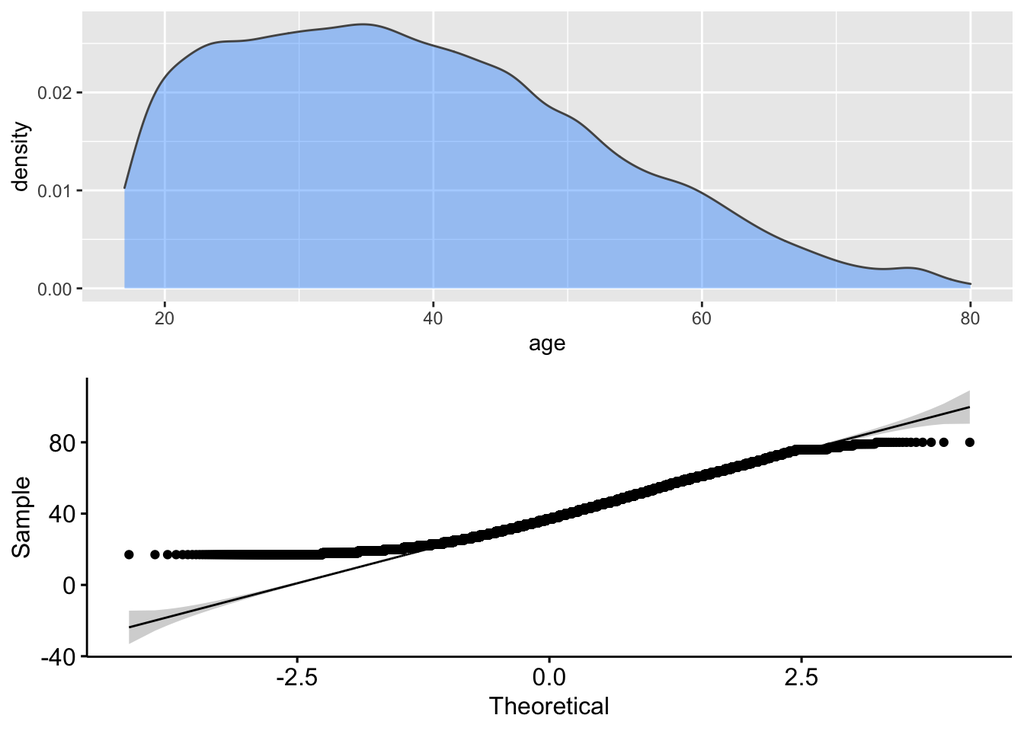

```r
library(gridExtra)
library(ggplot2)
library(ggpubr)

g1 <-  ggplot(data=censo, aes(x=age)) +
  geom_density(color="grey33", fill="dodgerblue", alpha=0.4)

g2 <-  ggqqplot(censo$age)



grid.arrange(g1, g2)
```

## 2.2. Normalidad

¿Podemos asumir normalidad para el cálculo del intervalo de confianza de la media de edad? Argumentad la respuesta.

> Con base en los gráficos mostrados si se puede asumir que no existe una distribución normal de la variable edad, sin embargo al ser una muestra lo suficientemente grande podemos fundamentar por el teorema del limite central que podemos tratar a la variable como normal.

## 2.3. Intervalo de confianza

Calculad manualmente el intervalo de confianza de la media de la variable age. Para ello, definid una función IC que reciba la variable, la confianza, y que devuelva un vector con los valores del intervalo de confianza

```r
IC <- function( x, alfa=0.05 ){
  n <- length(x)
  errorTipic <- sd(x) / sqrt( n )
  errorTipic

  t<-qnorm( 1-alfa/2 )
  t
  error <- t * errorTipic
  error
  return ( c( mean(x) - error, mean(x) + error ))
  }
```

## 2.4. Cálculos

Calculad el intervalo de confianza al 90 % y 95 %. Comparad los resultados.

```r
library(BSDA)

IC( censo$age, alfa=0.05 )
```

```
## [1] 38.40277 38.69698
```

```r
IC( censo$age, alfa=0.1 )
```

```
## [1] 38.42642 38.67333
```

Validacion

```r
z.test(censo$age, sigma.x=sd(censo$age))
```

```
##
##  One-sample z-Test
##
## data:  censo$age
## z = 513.63, p-value < 2.2e-16
## alternative hypothesis: true mean is not equal to 0
## 95 percent confidence interval:
##  38.40277 38.69698
## sample estimates:
## mean of x
##  38.54987
```

> Se puede observar que tanto la funcion construida como la propocionada de forma nativa por el paquete BSDA coinciden en sus resultados para el intervalo del 95% con lo que podemos asumir que la funcion es correcta.

## 2.5. Interpretación

Explicad cómo se interpreta el intervalo de confianza a partir de los resultados obtenidos.

# 3. Salario

Vamos a investigar ahora el salario de la población. En particular, nos preguntamos si en media, el salario de las personas Self-Employed es inferior al del resto de modalidades. Seguid los pasos que se especifican a continuación.

## 3.1. Pregunta de investigación

Formulad la pregunta de investigación.

> Existen una diferncia significativa e inferior en las medias de salarios para la poblacion de self-employed en comparcion con el resto de modalidades?

## 3.2. Hipótesis

Escribid las hipótesis (hipótesis nula e hipótesis alternativa).

> H0 : μSE = μnoSE

> H1 : μSE < μnoSE

## 3.3. Test a aplicar

Explicad qué tipo de test podéis aplicar dada la pregunta de investigación planteada y las características de la muestra. Justificad vuestra elección. Nota: Podéis usar las funciones de R que consideréis necesarias para responder esta pregunta.

> Aplicando el teorema del limite central, es posible asumir nomalidad de la variables ya que la muestra que disponemos es lo sufucientemente grande n=32,553 y se desea realizar un test sobre la media. Por tanto, aplicamos un test de hipótesis de dos muestras sobre la media. Aplicaremos la distribución t, dado que no se conoce la varianza de la población. Es necesario comprobar si podemos suponer varianzas iguales. Para ello, aplicamos el test var.test de R:

```r
var.test( censo$income[censo$workclass=="Self-Employed"], censo$income[censo$workclass!="Self-Employed"] )
```

```
##
##  F test to compare two variances
##
## data:  censo$income[censo$workclass == "Self-Employed"] and censo$income[censo$workclass != "Self-Employed"]
## F = 0.63242, num df = 3656, denom df = 28895, p-value < 2.2e-16
## alternative hypothesis: true ratio of variances is not equal to 1
## 95 percent confidence interval:
##  0.6026580 0.6642595
## sample estimates:
## ratio of variances
##          0.6324152
```

> Se descarta la igualdad de varainzas de las poblaciones al tener una p<0.001. Podemos aplicar entonces un test de dos muestras independientes sobre la media con varianza desconocida y diferente.

## 3.4. Cálculo

Calculad el test usando una función propia. Implementad una función que realice el cálculo del test y que podáis usar con distintos valores de nivel de confianza. Calculad el contraste para un nivel de confianza del 95 % y del 90 %. Mostrad los resultados (valor observado, crítico y valor p) en una tabla. Nota: No se pueden usar funciones como t.test para el cálculo. Sí podéis usar otras funciones básicas de R como mean, qnorm, qt, pnorm, pt, etcétera.

```r
library('kableExtra')

ttest <- function( x1, x2, CL=0.95 ){
#z test
mean1 <- mean(x1)
n1 <- length(x1)
sd1 <- sd(x1)
mean2 <- mean(x2)
n2 <- length(x2)
sd2 <- sd(x2)

Sb <- sqrt( sd1^2/n1 + sd2^2/n2 )
denom <- ( (sd1^2/n1)^2/(n1-1) + (sd2^2/n2)^2/(n2-1))
df <- ( (sd1^2/n1 + sd2^2/n2)^2 ) / denom

alfa <- (1-CL)
t <- (mean1-mean2) / Sb

tcritical <- qt( alfa, df, lower.tail=TRUE )
pvalue <- pt( t, df, lower.tail=TRUE )

result <- data.frame(t,tcritical,pvalue,df)
result %>% kable() %>% kable_styling()
return (result)
}
result <- ttest( censo$income[censo$workclass=="Self-Employed"], censo$income[censo$workclass!="Self-Employed"])
result
```

```
##         t tcritical pvalue       df
## 1 6.88972 -1.645145      1 5239.124
```

Comprobamos la funcion

```r
t.test( censo$income[censo$workclass=="Self-Employed"], censo$income[censo$workclass!="Self-Employed"], var.equal=FALSE, alternative = "less")
```

```
##
##  Welch Two Sample t-test
##
## data:  censo$income[censo$workclass == "Self-Employed"] and censo$income[censo$workclass != "Self-Employed"]
## t = 6.8897, df = 5239.1, p-value = 1
## alternative hypothesis: true difference in means is less than 0
## 95 percent confidence interval:
##       -Inf 0.8911684
## sample estimates:
## mean of x mean of y
##  49.39123  48.67183
```

## 3.5. Conclusión

A partir de los resultados obtenidos, dad respuesta a la pregunta de investigación.

# 4. Proporción de Self-Employed

Nos preguntamos si el porcentaje de Self-Employed en la población es superior al 10%. Aplicad el test necesario para dar respuesta a esta pregunta. Seguid los pasos que se indican a continuación.

## 4.1. Pregunta

Formulad la pregunta de investigación que se plantea en esta sección.

> El porcentaje de personas como modo de trabajo self-employed sera significativamente mayor al 10% en la poblacion?

## 4.2. Hipótesis

Escribid la hipótesis nula y la hipótesis alternativa.

> H0 : p = 0.1

> H1 : p > 0.1

> donde p es la proporción de personas que trabajando como self-employed.

## 4.3. Análisis visual

Representad de forma gráfica la proporción de Self-Employed en la muestra.

```r
table(censo$workclass)
```

```
##
##    Government Other/Unknown       Private Self-Employed
##          4349          1855         22692          3657
```

> Con esta data podemos generar el siguiente grafico.

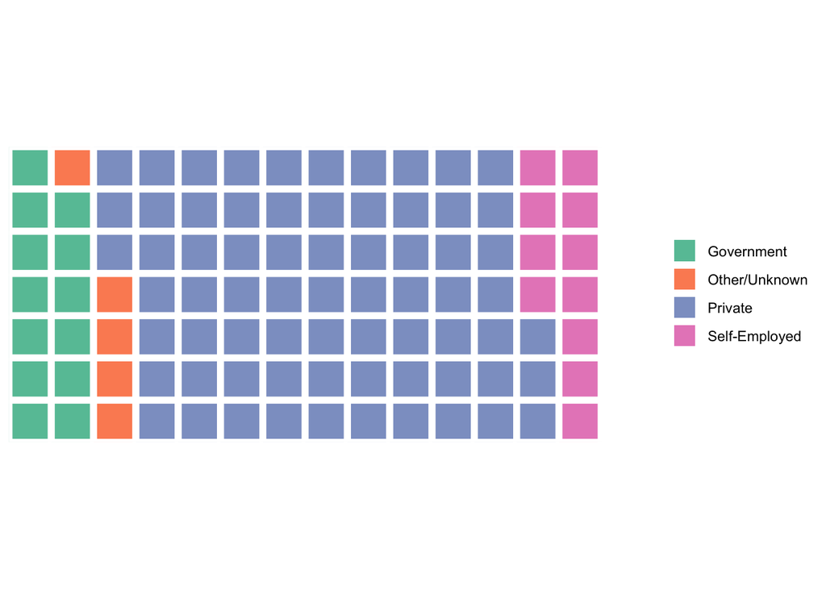

```r
library(waffle)

vals <- c('Government'=4349, "Other/Unknown"=1855, 'Private'=22692, 'Self-Employed'=3657)

waffle((vals/32553)*100, row=7)
```

> En el grafico se aprecia que en proporcion con la poblacion la mayoria de tipo de empleo se ubica en el sector privado, seguido de empleo gubernamental, luego autonomos y finalmente otros tipos de empleo.

## 4.4. Contraste

Explicad qué tipo de contraste podéis aplicar dada la pregunta de investigación planteada y las características de la muestra. Justificad vuestra elección.

> Se realiza un test de una muestra sobre la proporción. Se calcula la proporción de de autonmos en relacion con el total de la poblacion y se compruba si esa propocion es mayor al 0.10 con una significacion del 0.05.

## 4.5. Cálculo

Calculad el test usando una función propia. Podéis crear una función que reciba los parámetros necesarios y el nivel de confianza. Luego, calculad el contraste, llamando esta función, con nivel de confianza del 95 %. Mostrad los resultados (valor observado, crítico y valor p) en una tabla. Nota: No podéis usar prop.test o funciones ya implementadas en R. Sí podéis usar qnorm, qt, etcétera.

```r
pTest <- function(p, p0){

  pobs <- (p - p0)/ sqrt( p0*(1-p0)/n)

  z <- qnorm( 0.05, lower.tail=FALSE )

  pvalue <- pnorm( pobs, lower.tail=FALSE )
  cat("p=", p, "pobs=", pobs, "zcritical=", z, "pvalue=", pvalue)}


n <- nrow( censo )
p <- sum(censo$workclass == "Self-Employed") / n
p0 <- 0.1

pTest(p, p0)
```

```
## p= 0.1123399 pobs= 7.421387 zcritical= 1.644854 pvalue= 5.795014e-14
```

Validacion

```r
prop.test( x=3657, n=32553, p=0.10, correct=FALSE, alternative="greater" )
```

```
##
##  1-sample proportions test without continuity correction
##
## data:  3657 out of 32553, null probability 0.1
## X-squared = 55.077, df = 1, p-value = 5.795e-14
## alternative hypothesis: true p is greater than 0.1
## 95 percent confidence interval:
##  0.1094932 1.0000000
## sample estimates:
##         p
## 0.1123399
```

## 4.6. Conclusión

A partir de los resultados obtenidos, dad respuesta a la pregunta de investigación.

> El valor critico para un alfa de 0.05 es de 1.644854 y el valor observado es de 7.421387, con este valor se puede rechazar la hipotesis nula. Se puede afirmar asi que con un 95% de confianza el porcentaje de personal self-employed sera mayor al 10% de la poblacion.

# 5. Proporción de Self-Employed en mujeres y hombres

Nos preguntamos si la proporción de Self-Employed es menor entre las mujeres que entre los hombres en la población. Para dar respuesta a esta pregunta, seguid los pasos que se indican a continuación.

## 5.1. Pregunta de investigación

Formulad la pregunta de investigación que se plantea en esta sección.

> La proporcion de mujeres self-employed es menor al 0.5?

## 5.2. Análisis visual

Representad de forma gráfica la proporción de Self-Employed en la muestra de hombres y mujeres respectiva- mente.

```r
table(censo$workclass, censo$gender)
```

```
##
##                     f     m
##   Government     1638  2711
##   Other/Unknown   844  1011
##   Private        7751 14941
##   Self-Employed   534  3123
```

> Con esta data podemos generar el siguiente grafico.

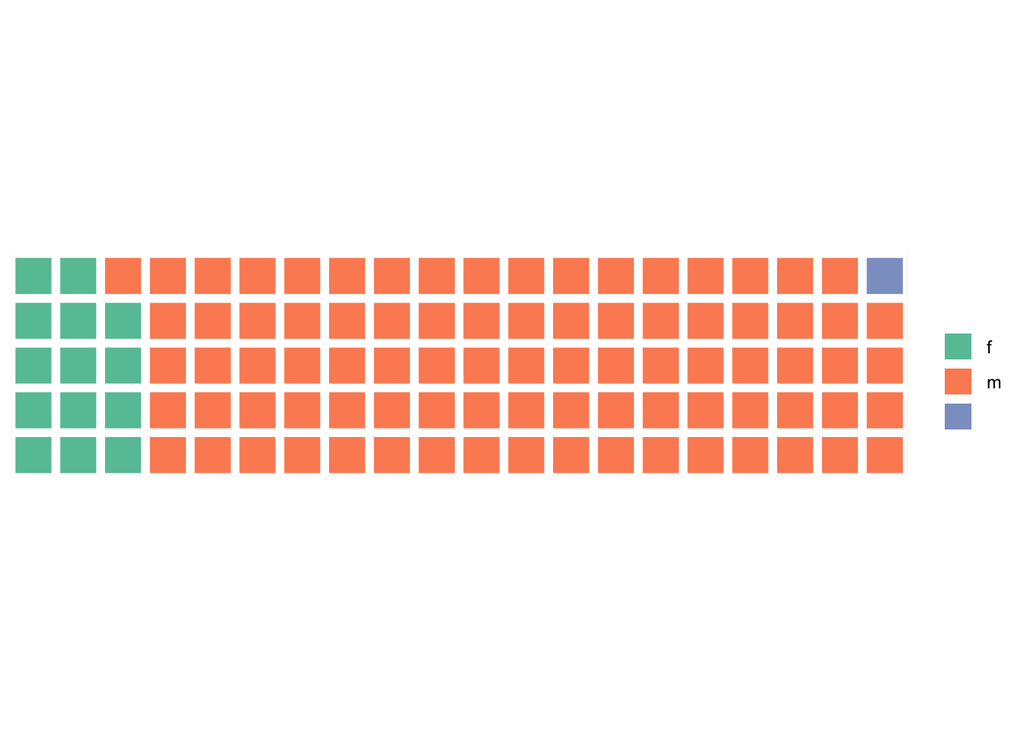

```r
library(waffle)

SE_by_gender <- c('f'=534, 'm'=3123)

waffle((SE_by_gender/3657)*100, row=5)
```

>En el grrafico podemos observar que la mayroia de personas delf-employed son de genero asculino.

## 5.3. Hipótesis

Escribid la hipótesis nula y la hipótesis alternativa.

> Ho: pM=pH

> Hi: pM<pH

## 5.4. Test

Explicad qué tipo de test podéis aplicar dada la pregunta de investigación planteada y las características de la muestra. Justificad vuestra elección.

> Se realiza un test de diferencias de dos grupos sobre la porporcion.

## 5.5. Cálculo

Calculad el test usando una función propia. Al igual que en apartados anteriores, se recomienda definir una función que realice el cálculo y que reciba los parámetros necesarios. Calculad el contraste para un nivel de confianza del 97 %. Mostrad los resultados (valor observado, crítico y valor p) en una tabla. Nota: No podéis usar funciones como prop.test o funciones ya implementadas en R para el contraste. Sí podéis usar funciones básicas como qnorm, qt, etcétera.

```r
pdifTest <- function(femenino, masculino, femenino_pos, masculino_pos, confianza) {

  nFem <- length(femenino)
  NMas <- length(masculino)

  pFem <- femenino_pos/nFem
  pMas <- masculino_pos/NMas

  p <- (nFem*pFem + NMas*pMas) /(nFem+NMas)

  q <- 1-p
  alfa <- 1-confianza

  zObs <- (pFem - pMas) / (sqrt((p*q/nFem) + (p*q/NMas)))

  zValue <- qnorm(alfa, lower.tail=TRUE)
  pvalor <- pnorm(zObs, lower.tail=TRUE)

  cat("zobs=", as.numeric(zObs), "zcritical=", as.numeric(zValue), "pvalue=", as.numeric(pvalor))

}

femenino <- censo$gender[censo$gender == 'f']
masculino <- censo$gender[censo$gender == 'm']
femenino_pos <- 534
masculino_pos <- 3123
confianza <- 0.97

pdifTest(femenino, masculino, femenino_pos, masculino_pos, confianza)
```

```
## zobs= -25.20201 zcritical= -1.880794 pvalue= 1.903638e-140
```

Validacion

```r
femenino <- length(censo$gender[censo$gender == 'f'])
masculino <- length(censo$gender[censo$gender == 'm'])
femenino_pos <- 534/femenino
masculino_pos <- 3123/masculino
confianza <- 0.97

success <- c(femenino*femenino_pos,masculino*masculino_pos)
n <- c(femenino,masculino)

prop.test(success, n, alternative="less", correct=FALSE, conf.level = confianza)
```

```
##
##  2-sample test for equality of proportions without continuity
##  correction
##
## data:  success out of n
## X-squared = 635.14, df = 1, p-value < 2.2e-16
## alternative hypothesis: less
## 97 percent confidence interval:
##  -1.00000000 -0.08780105
## sample estimates:
##     prop 1     prop 2
## 0.04959599 0.14334894
```

## 5.6. Conclusión

A partir de los resultados obtenidos, proporcionad una respuesta a la pregunta de investigación.

# 6. Dependencia Género - Self-Employed

Otra forma de abordar si existen diferencias en la proporción de Self-Employed según el género es realizando un test de independencia de dos variables cualitativas. Concretamente, nos preguntamos si el género y ser Self-Employed están relacionadas o se pueden considerar variables independientes. Las variables serían independientes si el género no influye en la proporción de Self-Employed, es decir, si no hay diferencias en las proporciones de Self-Employed según el género. En esta sección se pide aplicar el test de independencia Chi cuadrado para evaluar si las variables género y Self-Employed son independientes. Seguid los pasos que se indican a continuación.

## 6.1. Pregunta de investigación

Formulad la pregunta de investigación.

> Las variables género y Self-Employed están relacionadas?

## 6.2. Hipótesis

Escribid la hipótesis nula y alternativa.

> H0 : las variables género y Self-Employed son independientes.

> H1 : las variables género y Self-Employed están relacionadas.

## 6.3. Test

Describid brevemente en qué consiste el test chi cuadrado. Calculad la matriz de contingencia y mostrad sus valores.

> El test de chi cuadrado se basa en el analisis de matrices de contingencia para determinar si dos variables son dependientes o independientes entre si. El analisis comparar una tabla de contingencia esperada si las variables son independientes vs la contingencia real para aceptar o rechazar la hipotesis nula. A continuacion la matriz de contigencia observada.

```r
censo$workclass[censo$workclass!="Self-Employed"] <- "No-Self-Employed"

table(censo$workclass, censo$gender)
```

```
##
##                        f     m
##   No-Self-Employed 10233 18663
##   Self-Employed      534  3123
```

## 6.4. Cálculos

Realizad los cálculos del test Chi cuadrado, implementando una función propia. Calculad el contraste para un nivel de confianza de 97 %. Nota: No podéis usar la función chisq.test de R. Sí podéis usar pchisq para consultar los valores de la distribución.

```r
chi2test <- function(obs_data){
  sr <- rowSums(obs_data)
  sc <- colSums(obs_data)
  exp_data <- outer(sr, sc, "*")/sum(obs_data)
  x2 <-sum((obs_data-exp_data)^2/exp_data)
  pvalue <- pchisq(q=x2, df=(nrow(obs_data)-1)*(ncol(obs_data)-1), lower.tail = F)
  cat("X2=", x2, 'pvalue=', pvalue)

}

data <- matrix(c(10233, 534,
                     18663, 3123),
                     nrow = 2,
                     dimnames = list(
                                     c("No-Self-Employed", "Self-Employed"),
                                     c('f','m')))


chi2test(data)
```

```
## X2= 635.1414 pvalue= 3.807275e-140
```

## 6.5. Conclusión

Responded la pregunta de investigación planteada en este apartado. Relacionad el resultado con la aproximación de la sección anterior, donde se realiza un test sobre las proporciones.

> El pvalor para un chi cuadrado de 635.1414 resulta ser 3.807275e-140 siendo bastantante menor de 0.03 con lo que rechanzamos la hipotesis nula, es decir confirmamos los resultados del test anterior siendo que las variables genero y self-employment si son dependientes entre si.

# 7. Resumen y conclusiones

Presentad una tabla con los resultados principales de cada sección: la pregunta de investigación planteada, los valores obtenidos del contraste y la conclusión obtenida en cada apartado. La tabla puede tener un formato como el que se muestra a continuación (se aporta un ejemplo para la primera fila de datos).

[output not shown]